# CXR in COVID Analysis

## Intermodality Agreement

###### This section contains code to analyse the level of agreement in the unmatched CT dataset which contains only data with CT, XR and RT-PCR

###### First- comparing CT and XR agreement

```r
library(irr)
 kappa2(c(CTdata$XRPositive,CTdata$CTPositive), weight = "squared")
 d<-CTdata %>% select(c("CTPositive","XRPositive"))
 View(d)
 kappa2(d, weight = "squared")
```

###### Output:

```r
 Cohen's Kappa for 2 Raters (Weights: squared)

 Subjects = 287
   Raters = 2
    Kappa = 0.406

        z = 7.14
  p-value = 9.37e-13
```

###### The following code compares RT-PCR, CT and XR

```r
 d2<-CTdata %>% select(c("CTPositive","XRPositive","OverallPos"))
 View(d2)
 kappam.fleiss(d2)
```

###### Output:

```r
 Fleiss' Kappa for m Raters

 Subjects = 287
   Raters = 3
    Kappa = 0.361

        z = 10.6
  p-value = 0
```

### Diagnostic Accuracy Analysis when Indeterminate Reports of CXR and CT are taken as positive

#### XR Indeterminates

###### New column for positive if indeterminate

```r
stacked$XRIndPositive<-ifelse(stacked$XRChest=="Classic COVID" | stacked$XRChest == "Indeterminate",
                              "Positive","Negative")
stacked$XRIndPositive<-as.factor(stacked$XRIndPositive)
stacked %>% filter(OverallPos == "Positive")->stackedpos
stacked %>% filter(OverallPos == "Negative")->stackedneg
summary(stackedpos$XRIndPositive)
summary(stackedneg$XRIndPositive)

contingxrind<-matrix(c(441,107,186,126),nrow = 2,ncol = 2)
colnames(contingxrind) <- c("PCR+", "PCR-")

rownames(contingxrind) <- c("XR+", "XR-")
epi.tests(contingxrind)->xrindaccuracy
```

###### In this section mean differences of diagnostic accuracy statistics between CT (when CT indeterminates are not counted as positive)and Chest X-ray with confidence intervals and p-values are calculated, follows the same pattern as code previously

```r
###### Sensitivity
###### Upper confidence limit for difference in sensitivity

ubsens<-(ctaccuracy[["elements"]][["se.up"]]-xrindaccuracy[["elements"]][["se.low"]])
##Lower confidence limit for difference in sensitivity
lbsens<-(ctaccuracy[["elements"]][["se.low"]]-xrindaccuracy[["elements"]][["se.up"]])
##Mean difference in sensitivity
meansens<-ctaccuracy[["elements"]][["se"]]-xrindaccuracy[["elements"]][["se"]]
##Standard error for sensitivity
sesens<-(ubsens-lbsens)/(2*1.96)
##Z value for difference in sensitivity
meansens/sesens->zsens
##P-value for difference in sensitivity
psens <- exp(-0.717*zsens - 0.416*zsens^2)
###Format values into 'mean difference (95% CI) p-value' rounded to 2 d.p.
sprintf("%s (%s-%s)",
        round(meansens, digits = 2), round(lbsens, digits = 2),
        round(ubsens, digits = 2))->diffsens
diffsensp<-c(diffsens,psens)

###Subsequent analyses in this section follow the code above
##Specificity
ubspec<-(ctaccuracy[["elements"]][["sp.up"]]-xrindaccuracy[["elements"]][["sp.low"]])
lbspec<-(ctaccuracy[["elements"]][["sp.low"]]-xrindaccuracy[["elements"]][["sp.up"]])
meanspec<-ctaccuracy[["elements"]][["sp"]]-xrindaccuracy[["elements"]][["sp"]]
sespec<-(ubspec-lbspec)/(2*1.96)
meanspec/sespec->zspec
pspec <- exp(-0.717*zspec - 0.416*zspec^2)
sprintf("%s (%s-%s)",
        round(meanspec, digits = 2), round(lbspec, digits = 2),
        round(ubspec, digits = 2))->diffspec
diffspecp<-c(diffspec,pspec)


ubda<-(ctaccuracy[["elements"]][["da.up"]]-xrindaccuracy[["elements"]][["da.low"]])
lbda<-(ctaccuracy[["elements"]][["da.low"]]-xrindaccuracy[["elements"]][["da.up"]])
meanda<-ctaccuracy[["elements"]][["da"]]-xrindaccuracy[["elements"]][["da"]]
seda<-(ubda-lbda)/(2*1.96)
meanda/seda->zda
pda <- exp(-0.717*zda - 0.416*zda^2)
sprintf("%s (%s-%s)",
        round(meanda, digits = 2), round(lbda, digits = 2),
        round(ubda, digits = 2))->diffda
diffdap<-c(diffda,pda)
##Positive Likelihood Ratio
ublrpos<-(ctaccuracy[["elements"]][["lrpos.up"]]-xrindaccuracy[["elements"]][["lrpos.low"]])
lblrpos<-(ctaccuracy[["elements"]][["lrpos.low"]]-xrindaccuracy[["elements"]][["lrpos.up"]])
meanlrpos<-ctaccuracy[["elements"]][["lrpos"]]-xrindaccuracy[["elements"]][["lrpos"]]
selrpos<-(ublrpos-lblrpos)/(2*1.96)
meanlrpos/selrpos->zlrpos
plrpos <- exp(-0.717*zlrpos - 0.416*zlrpos^2)
sprintf("%s (%s-%s)",
        round(meanlrpos, digits = 2), round(lblrpos, digits = 2),
        round(ublrpos, digits = 2))->difflrpos
difflrposp<-c(difflrpos,plrpos)
##Negative Likelihood Ratios
ublrneg<-(ctaccuracy[["elements"]][["lrneg.up"]]-xrindaccuracy[["elements"]][["lrneg.low"]])
lblrneg<-(ctaccuracy[["elements"]][["lrneg.low"]]-xrindaccuracy[["elements"]][["lrneg.up"]])
meanlrneg<-ctaccuracy[["elements"]][["lrneg"]]-xrindaccuracy[["elements"]][["lrneg"]]
selrneg<-(ublrneg-lblrneg)/(2*1.96)
meanlrneg/selrneg->zlrneg
plrneg <- exp(-0.717*zlrneg - 0.416*zlrneg^2)
sprintf("%s (%s-%s)",
        round(meanlrneg, digits = 2), round(lblrneg, digits = 2),
        round(ublrneg, digits = 2))->difflrneg
difflrnegp<-c(difflrneg,plrneg)


##Positive Predictive Value
ppv<-(ctaccuracy[["elements"]][["ppv.low"]]-xrindaccuracy[["elements"]][["ppv.up"]])
meanppv<-ctaccuracy[["elements"]][["ppv"]]-xrindaccuracy[["elements"]][["ppv"]]
seppv<-(ubppv-lbppv)/(2*1.96)
meanppv/seppv->zppv
pppv <- exp(-0.717*zppv - 0.416*zppv^2)
sprintf("%s (%s-%s)",
        round(meanppv, digits = 2), round(lbppv, digits = 2),
        round(ubppv, digits = 2))->diffppv
diffppvp<-c(diffppv,pppv)

##Negative Predictive Value
npv<-(ctaccuracy[["elements"]][["npv.low"]]-xrindaccuracy[["elements"]][["npv.up"]])
meannpv<-ctaccuracy[["elements"]][["npv"]]-xrindaccuracy[["elements"]][["npv"]]
senpv<-(ubnpv-lbnpv)/(2*1.96)
meannpv/senpv->znpv
pnpv <- exp(-0.717*znpv - 0.416*znpv^2)
sprintf("%s (%s-%s)",
        round(meannpv, digits = 2), round(lbnpv, digits = 2),
        round(ubnpv, digits = 2))->diffnpv
diffnpvp<-c(diffnpv,pnpv)


##True Prevalence
meantp<-ctaccuracy[["elements"]][["tp"]]-xrindaccuracy[["elements"]][["tp"]]
setp<-(ubtp-lbtp)/(2*1.96)
meantp/setp->ztp
ptp <- exp(-0.717*ztp - 0.416*ztp^2)
sprintf("%s (%s-%s)",
        round(meantp, digits = 2), round(lbtp, digits = 2),
        round(ubtp, digits = 2))->difftp
difftpp<-c(difftp,ptp)

##Apparent Prevalence
meanap<-ctaccuracy[["elements"]][["ap"]]-xrindaccuracy[["elements"]][["ap"]]
seap<-(ubap-lbap)/(2*1.96)
meanap/seap->zap
pap <- exp(-0.717*zap - 0.416*zap^2)
sprintf("%s (%s-%s)",
        round(meanap, digits = 2), round(lbap, digits = 2),
        round(ubap, digits = 2))->diffap
diffapp<-c(diffap,pap)
```

#### CT Indeterminates

###### New column for positive if indeterminate

```r
CTdata$CTIndPositive<-ifelse(CTdata$CTBSTI=="1" | CTdata$CTBSTI == "2",
                              "Positive","Negative")
CTdata$CTIndPositive<-as.factor(CTdata$CTIndPositive)
CTdata %>% group_by(OverallPos, CTIndPositive) %>% summarise(n=n())->valuesctind
ctcontingind<-matrix(data = c(178,13,70,41),
                     nrow = 2, ncol = 2)

colnames(ctcontingind)<-c("PCR+ve","PCR-ve")
rownames(ctcontingind)<-c("CT+ve","CT-ve")
epi.tests(ctcontingind)->ctindaccuracy
```

## Pooled Regression after Multiple Imputation and Propensity Score Matching

###### Binomnal Logistic regression with RT-PCR as dependent variable

```r
matchedtest %>% with(glm(formula(ff_formula(dependent = "OverallPos",
                      explanatory = c("Age",
                                     "Ethnicity",
                                     "Sex",
                                     "RR",
                                     "GCS",
                                     "Temperature",
                                     "HR",
                                     "SystolicBP",
                                     "Neutrophils",
                                     "DDimer",
                                     "CRP",
                                     "Troponin",
                                     "Albumin",
                                     "CK",
                                     "Sats",
                                     "Admitted",
                                     "AdmittedToITU",
                                     "ThirtyDayFUTwo",
                                     "Dyspnoea",
                                     "Comorbidity",
                                     "XRChest"))),
      family = "binomial"), all = FALSE)->overallposmatchimp
overallposmatchimp %>% pool()->P
multivarpooledoverallpos = P %>%
  fit2df(estimate_name = "OR (multiple imputation)", exp = TRUE)
```

###### ‘multivarpooledoverallpos’ produces multivariate odds ratios for each explanatory variable, corresponding to Table 4

### Pooled Univariate Odds Ratios for OverallPos as dependent variable

###### This code is run with each of the explanatory variables in table 4 as arguments to produce their respective odds Ratios in table 4

```r
matchedtest %>% with(glm(formula(ff_formula(dependent = "OverallPos",
                                         explanatory = "XRChest"
                                                        )),
                      family = "binomial"))->overallposmatchimpunivar
overallposmatchimpunivar %>% pool()->P
univarpooledoverallpos = P %>%
  fit2df(estimate_name = "OR (univariate)", exp = TRUE)->univaroverallpos
univaroverallpos
```

### Binomial Logistic Regression with Positive Chest X-ray Report as Dependent Variable

###### This code follows the format above to produce univariate and multivariate odds ratios for each explanatory variable for having a positive XR report

### Univariate XRPositive as dependent

###### (different explanatory variables passed into function to produce Odds ratios for each)

```r
matchedtest %>% with(glm(formula(ff_formula(dependent = "XRPositive",
                                         explanatory = "Comorbidity"
)),
family = "binomial"))->XRChestmatchimp
XRChestmatchimp %>% pool()->P
multivarpooledXRChest = P %>%
  fit2df(estimate_name = "OR (univariate)", exp = TRUE)->univarXRChest
univarXRChest
```

### Multivariate XRPositive as dependent

```r
matchedtest %>% with(glm(formula(ff_formula(dependent = "XRPositive",
                                         explanatory = c("Age",
                                         "OverallPos",
                                         "Ethnicity",
                                         "Sex",
                                         "RR",
                                         "GCS",
                                         "Temperature",
                                         "HR",
                                         "SystolicBP",
                                         "Neutrophils",
                                         "DDimer",
                                         "CRP",
                                         "Troponin",
                                         "Albumin",
                                         "CK",
                                         "Sats",
                                         "Admitted",
                                         "AdmittedToITU",
                                         "ThirtyDayFUTwo",
                                         "Dyspnoea",
                                         "Comorbidity")
)),
family = "binomial"))->XRChestmatchimp
XRChestmatchimp %>% pool()->P
multivarpooledXRChest = P %>%
  fit2df(estimate_name = "OR (multivariate)", exp = TRUE)->multivarXRChest
multivarXRChest
```

###### This code also produces multivariate odds ratios for table 5, however, uses ordinal linear regression after the CXR report variable is converted to an ordered categorical variable, with alternative pathology as the lowest and classic covid as the highest value (see table 3)

```r
matchedtest %>% with(clm(formula = XRChest ~ Age +
                                                         OverallPos+
                                                         Ethnicity+
                                                         Sex+
                                                         RR+
                                                         GCS+
                                                         Temperature+
                                                         HR+
                                                         SystolicBP+
                                                         Neutrophils+
                                                         DDimer+
                                                         CRP+
                                                         Troponin+
                                                         Sats+
                                                         Admitted+
                                                         AdmittedToITU+
                                                         ThirtyDayFUTwo+
                                                         Dyspnoea+
                                                         Comorbidity))->XRChestmatchimpord
pool(object = XRChestmatchimpord[["analyses"]])->P
multivarpooledXRChestord = P %>%
  fit2df(estimate_name = "OR (multivariate)", exp = TRUE)->multivarXRChestord
multivarXRChestord
```

## Forest Plots

###### Creates forest plots for post matched regression tables above:

```r
Figure1Forest <- read_excel("Figure1Forest.xlsx",
                            col_types = c("text", "numeric", "numeric",
                                          "numeric", "text", "text"))

tabletext1<-cbind(Figure1Forest$explanatory, Figure1Forest$summary)
forestplot (tabletext1, Figure1Forest$Mean,
           Figure1Forest$Lower, Figure1Forest$Upper, is.summary = FALSE,
clip = c(0, 2),
           xlab="\u2190 Decreased Odds SARS-CoV 2       Increased Odds SARS-CoV 2 \u2192",
           zero=1, cex=0.9, lineheight = unit(6,"mm"), boxsize=0.4, colgap=unit(6,"mm"),
           lwd.ci=2, ci.vertices=TRUE, ci.vertices.height = 0.4,
title="Odds Ratio of Positivity for SARS-CoV 2 by RT-PCR",
txt_gp=fpTxtGp(label=gpar(cex=1.25),
               ticks=gpar(cex=1.1),
               xlab=gpar(cex = 1.2),
               title=gpar(cex = 1.2)),
graphwidth = unit(200,"mm")
)
```

###### Figure 1:

[figure not shown]

###### Figure 2 (XR dependent):

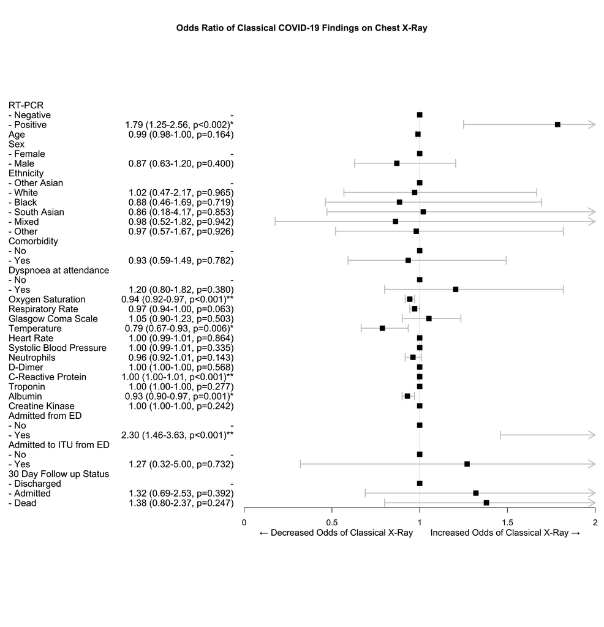

```r
Figure2Forest <- read_excel("Figure2Forest.xlsx",
                            col_types = c("text", "numeric", "numeric",
                                          "numeric", "text", "text"))

tabletext2<-cbind(Figure2Forest$explanatory,Figure2Forest$summary)
forestplot (tabletext2, Figure2Forest$Mean,
            Figure2Forest$Lower, Figure2Forest$Upper, is.summary = FALSE,
            clip = c(0, 2),
            xlab="\u2190 Decreased Odds of Classical X-Ray       Increased Odds of Classical X-Ray \u2192",
            zero=1, cex=0.9, lineheight = unit(6,"mm"), boxsize=0.5, colgap=unit(6,"mm"),
            lwd.ci=2, ci.vertices=TRUE, ci.vertices.height = 0.4,
            title="Odds Ratio of Classical COVID-19 Findings on Chest X-Ray",
            txt_gp=fpTxtGp(label=gpar(cex=1.25),
                           ticks=gpar(cex=1.1),
                           xlab=gpar(cex = 1.2),
                           title=gpar(cex = 1.2)),
            graphwidth = unit(200,"mm")

)
```

## Correlation Matrix

###### This section creates a plot of correlation between all the variables in the raw data

```r
library(corrplot);library(Hmisc)
```

###### Relevel factors so relevant value is first

```r
relevel(data$XRPositive, "Negative")->data$XRPositive

relevel(data$Admitted, "Discharged")->data$Admitted
relevel(data$AdmittedToITU, "No")->data$AdmittedToITU
```

###### New variable for correlation matrix

```r
cor<-data
```

###### Remove variables with high missings/ data which won’t work e.g. date, RT-PCR removed as it only represents initial ED swab, OverallPos used instead as this includes susequent swabs in 30 days

```r
cor<-subset(data, select = -c(CT,DateOfDeath,DateOfDischarge,RTPCR,
                             DateOfVisit,DateOfSymptomOnset,FollowUpPos,TimeToDeath,NEWS))'
```

###### Format and re-name values

```r
cor$CTPositive <-
  ifelse(cor$CTBSTI == "1", "Positive", "Negative")
cor$CTPositive<-as.factor(cor$CTPositive)
cor$CTPositive<-relevel(cor$CTPositive,"Negative")
cor$Death<-as.factor(ifelse(cor$ThirtyDayFU == "4", "Dead", "Alive"))
relevel(cor$Death, "Alive")->cor$Death
cor$OverallPos<-as.factor(cor$OverallPos)
cor<-sapply(cor, as.numeric)
```

###### Create new numerical correlation matrix

```r
cor(cor, method = "spearman", use = "pairwise.complete.obs")->cormatrixall
```

###### This variable also contains p-values so identification of only significant correlations is possible:

```r
cormatrixall2 <- rcorr(as.matrix(cor), type ="spearman")
```

###### Function to create and format correlation matrix plot

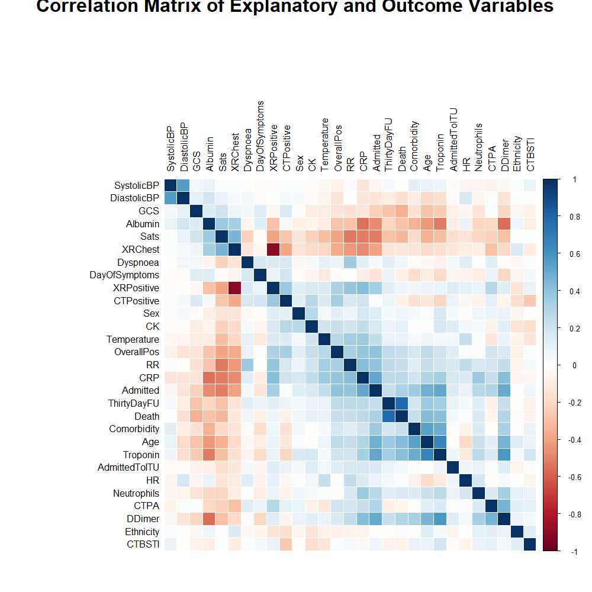

```r
corrplot(cormatrixall2$r, method = "color", type = "full", order = "hclust",
         p.mat = cormatrixall2$p, sig.level = 0.05, insig = "blank",
         tl.col = "black", outline = "white",
         title = "Correlation Matrix of Explanatory and Outcome Variables",
         line = -1, cex.main = 2, adj.main = 0.5)
```